# Markdown - Breaking in or Breaking Through? How Local Specialisations Shape the Integration of AI Technologies

# 1. Technological Spaces based on Technological field

## 1.1. Calculate Specializations for Different Time intervals

In this first part, we load the very large datasets containing patent data and inventor’s location, and use them to calculate specialisations and ultimately create the Global technological space (GTS) and the AI-specific technological space (ATS). We calculate specialisations per interval.

We start by defining custom functions and loading the first part of the large patent dataset with inventors’ location.

The patent file with inventors’ location looks like this:

```r
head(ipc_all_patents_part2_df)
```

| appln_id | ctry_code | techn_field_nr | weight | priority_year |
| --- | --- | --- | --- | --- |
| 203438 | JP | 2 | 9 | 2000 |
| 203438 | JP | 2 | 9 | 2000 |
| 203438 | JP | 9 | 1 | 2000 |
| 203438 | JP | 9 | 1 | 2000 |
| 203521 | US | 15 | 375 | 1996 |
| 203521 | US | 16 | 625 | 1996 |

The weight column was downloaded from patstat, but it it’s totally irrelevant and it will be calculated again later. We load next the data on AI patents (file “other_files/IPCs_AI.csv”). It looks like this:

```r
head(ai_patents_df)
```

| appln_id | appln_id2 | patent_office | priority_year | ctry_code | source | kinds | appln_id3 | ipc_class_symbol | ipc_class_level | ipc_version | ipc_value | ipc_position | ipc_gener_auth |
| --- | --- | --- | --- | --- | --- | --- | --- | --- | --- | --- | --- | --- | --- |
| 475222998 | 475222998 | CN | 2016 | AI_pat | 7 | single | 475222998 | G06F 17/22 | A | 01/01/2006 | I | L | CN |
| 475222998 | 475222998 | CN | 2016 | AI_pat | 7 | single | 475222998 | G06F 17/24 | A | 01/01/2006 | I | L | CN |
| 475222998 | 475222998 | CN | 2016 | AI_pat | 7 | single | 475222998 | G06F 17/27 | A | 01/01/2006 | I | L | CN |
| 475222998 | 475222998 | CN | 2016 | AI_pat | 7 | single | 475222998 | G06F 17/30 | A | 01/01/2006 | I | F | CN |
| 475222998 | 475222998 | CN | 2016 | AI_pat | 7 | single | 475222998 | G06F 19/00 | A | 01/01/2011 | I | L | CN |
| 475222998 | 475222998 | CN | 2016 | AI_pat | 7 | single | 475222998 | G06N 3/08 | A | 01/01/2006 | I | L | CN |

We also load the IPC file with information about technological fields (file “other_files/ipc_technology.csv”), which after processing looks like this:

```r
head(ipc_names_df)
```

|  | field_nr | sector | field_name | techn_field_nr |
| --- | --- | --- | --- | --- |
| 1 | 1 | Electrical engineering | Electrical machinery, apparatus, energy | 1 |
| 2 | 2 | Electrical engineering | Audio-visual technology | 2 |
| 3 | 3 | Electrical engineering | Telecommunications | 3 |
| 4 | 4 | Electrical engineering | Digital communication | 4 |
| 5 | 5 | Electrical engineering | Basic communication processes | 5 |
| 6 | 6 | Electrical engineering | Computer technology | 6 |

Now we’ll start calculating the specialisations of countries and AI technologies per interval. We have three intervals, the first being from 1974 to 1988, the second from 1989 to 2003, and the third from 2004 to 2018. We start by breaking the large patent file into it’s corresponding interval, and applying the two custom functions over it (group_by_applnID and group_by_ctry_and_techn_field).

The first function (group_by_applnID) groups data by application ID, and within each group, calculates a field-specific weight equal to 1 divided by the number of technological fields in that group. After applying this function over our interval-specific patent data, it looks like this:

```r
head(region_tech_fields_1_df)
```

| appln_id | ctry_code | techn_field_nr | field_weight |
| --- | --- | --- | --- |
| 206163 | DE | 1 | 0.50 |
| 206163 | DE | 1 | 0.50 |
| 214019 | FR | 9 | 0.25 |
| 214019 | FR | 9 | 0.25 |
| 214019 | FR | 29 | 0.25 |
| 214019 | FR | 29 | 0.25 |

Next we apply the second function (group_by_ctry_and_techn_field), which aggregates the weighted fields at the country-technology field level. After applying it, the data looks like this:

```r
head(region_tech_fields_1_df)
```

| ctry_code | techn_field_nr | n_tech_reg |
| --- | --- | --- |
| AD | 20 | 1 |
| AD | 24 | 1 |
| AD | 28 | 3 |
| AD | 32 | 1 |
| AD | 33 | 1 |
| AD | 34 | 3 |

This file is saved as a csv for being used later (for this first interval, the name and location of the file is “Files_created_with_the_code/data/files_code_Fields_analysis/reg_tech_FirstPeriod.csv”). We use this file in the next calculation, in which we create a matrix from this aggregated data. The matrix counts the name of registers of each country in which possible technological field. It looks like this:

```r
print(as.matrix(mat_reg_tech1[1:20, 1:12]))
```

```
##       1    2    3   4   5   6  7   8    9   10  11   12
## AG    1    0    0   0   0   0  0   0    0    0   0    0
## AM    1    0    0   0   0   0  0   0    0    0   0    0
## AR   11    7    6   1   2   2  0   0    3   12   1    6
## AT  758  299  198  23 131  64  1  28  279  461  38  130
## AU 1403  606  409  48 178 272 10  81  509 1321 149  659
## BA    0    0    0   0   0   0  0   0    0    0   0    0
## BB    0    0    0   0   0   0  0   0    0    1   0    0
## BE  261   97  159  32  54  43  0  26  182  196  65   80
## BG  992  335  166  36 333 455  0 114  228 1284 137  340
## BI    1    0    0   0   0   0  0   0    0    0   0    0
## BM    2    2    0   0   0   0  0   0    0    0   0    0
## BO    2    0    0   0   0   0  0   0    0    1   0    1
## BR 1759  647  754  47 138 325 12  50  296  962  48  851
## BS    4    0    0   0   0   0  0   0    0    0   0    0
## BU    0    0    0   0   0   0  0   0    0    1   0    0
## CA 3827 1409 1474 254 553 784 14 372 1368 2915 252 1041
## CH 2194  788  372 108 299 242  4 225  841 2526 120  754
## CL    0    1    1   0   0   1  0   0    1    1   0    2
## CN  931  233  146  20 106 317  0 132  306  994  45  223
## CO    8    2    0   0   0   0  0   0    0    0   0    4
```

We finally use this matrix to calculate the general specialisations (RTA indexes, which stands for Revealed Technological Advantage) of countries in this first interval. The RTA is set to be non-binary, and the data looks like this after this calculation:

```r
head(reg_RCA1_df)
```

| ctry_code | techn_field_nr | RCA |
| --- | --- | --- |
| AG | 1 | 6.4097284 |
| AM | 1 | 12.8194569 |
| AR | 1 | 0.4209374 |
| AT | 1 | 0.7479332 |
| AU | 1 | 0.4791203 |
| BA | 1 | 0.0000000 |

We do the same for the specialisations of countries in AI considering the AI patents in this interval. The steps are pretty much the same: we separate the AI data into this specific interval (ai_patents_df), apply the two custom functions (group_by_applnID and group_by_ctry_and_techn_field), save the file (“Files_created_with_the_code/data/files_code_Fields_analysis/Data1period_RCA_techn_field.csv”), create a matrix, and use it to calculate countries’ specialisations in AI for this period. The AI-related specialisations data looks like this:

```r
head(reg_RCA1_AI_df)
```

| ctry_code | techn_field_nr | RCA |
| --- | --- | --- |
| AT | 1 | 0 |
| AT | 10 | 0 |
| AT | 11 | 0 |
| AT | 12 | 0 |
| AT | 13 | 0 |
| AT | 17 | 0 |

We merge this data with the “general” specialisations calculated earlier. The resulting file and an additional example for the case of Japan look like this:

```r
#Resulting file:
head(rca_data_period_1_df)
```

|  | ctry_code | techn_field_nr | RCA_Gen | RCA_AI | Period |
| --- | --- | --- | --- | --- | --- |
| 1 | AD | 1 | 0 | NA | 1974-1988 |
| 2 | AD | 10 | 0 | NA | 1974-1988 |
| 3 | AD | 11 | 0 | NA | 1974-1988 |
| 4 | AD | 12 | 0 | NA | 1974-1988 |
| 5 | AD | 13 | 0 | NA | 1974-1988 |
| 6 | AD | 14 | 0 | NA | 1974-1988 |

```r
#Example Japan:
head(rca_data_period_1_df[rca_data_period_1_df$ctry_code == "JP",])
```

|  | ctry_code | techn_field_nr | RCA_Gen | RCA_AI | Period |
| --- | --- | --- | --- | --- | --- |
| 2731 | JP | 1 | 1.1268685 | 1.4025974 | 1974-1988 |
| 2732 | JP | 10 | 1.0109760 | 1.2022263 | 1974-1988 |
| 2733 | JP | 11 | 0.7067914 | 0.0000000 | 1974-1988 |
| 2734 | JP | 12 | 1.0644547 | 1.0957792 | 1974-1988 |
| 2735 | JP | 13 | 0.6104061 | 0.7012987 | 1974-1988 |
| 2736 | JP | 14 | 0.6177233 | NA | 1974-1988 |

We save this data for later usage (“Files_created_with_the_code/data/files_code_Fields_analysis/Data1period_RCA_techn_field.csv”). Next, we turn to the AI-specific specialisations of this interval. We pick our AI data for this interval and replace their country codes by a new “AI-specific” fake code named AI_pat. This allows us to calculate specialisations for AI as it were a country exploring distinct technologies. We apply the same two custom functions over it (group_by_applnID and group_by_ctry_and_techn_field), and get the following resulting file with the AI specialisations:

```r
head(region_tech_ai_1_df[region_tech_ai_1_df$ctry_code == "AI_pat",])
```

| ctry_code | techn_field_nr | n_tech_reg |
| --- | --- | --- |
| AI_pat | 1 | 1.750000 |
| AI_pat | 2 | 2.250000 |
| AI_pat | 3 | 3.533333 |
| AI_pat | 4 | 2.750000 |
| AI_pat | 5 | 12.916667 |
| AI_pat | 6 | 279.433333 |

We also save this file for later usage (“Files_created_with_the_code/data/files_code_Fields_analysis/reg_techAI_FirstPeriod.csv”). We do the exact same thing for the two remaining intervals (namely Interval 2 [1989-2003], and Interval 3 [2004-2018]), saving corresponding interval-specific files throughout the process. At the end, we combine the three interval-specific files with countries’ general and AI-specific specialisations (namely rca_data_period_1_df, rca_data_period_2_df, rca_data_period_3_df) into a single file named ipc_rcas_df, which we also save (“Files_created_with_the_code/data/files_code_Fields_analysis/IPC_RCAs.csv”). Using again the case of Japan as an example and considering each of the three intervals, the combined and saved ipc_rcas_df file looks like this:

```r
head(IPC_RCAs[IPC_RCAs$ctry_code == "JP" & IPC_RCAs$Period == "1974-1988",])
```

|  | ctry_code | techn_field_nr | RCA_Gen | RCA_AI | Period |
| --- | --- | --- | --- | --- | --- |
| 2731 | JP | 1 | 1.1268685 | 1.4025974 | 1974-1988 |
| 2732 | JP | 10 | 1.0109760 | 1.2022263 | 1974-1988 |
| 2733 | JP | 11 | 0.7067914 | 0.0000000 | 1974-1988 |
| 2734 | JP | 12 | 1.0644547 | 1.0957792 | 1974-1988 |
| 2735 | JP | 13 | 0.6104061 | 0.7012987 | 1974-1988 |
| 2736 | JP | 14 | 0.6177233 | NA | 1974-1988 |

```r
head(IPC_RCAs[IPC_RCAs$ctry_code == "JP" & IPC_RCAs$Period == "1989-2003",])
```

|  | ctry_code | techn_field_nr | RCA_Gen | RCA_AI | Period |
| --- | --- | --- | --- | --- | --- |
| 9486 | JP | 1 | 1.1395992 | 0.9834465 | 1989-2003 |
| 9487 | JP | 10 | 1.0147327 | 0.8904603 | 1989-2003 |
| 9488 | JP | 11 | 0.6029495 | 0.6173858 | 1989-2003 |
| 9489 | JP | 12 | 1.0394907 | 0.9396071 | 1989-2003 |
| 9490 | JP | 13 | 0.5833007 | 0.5805270 | 1989-2003 |
| 9491 | JP | 14 | 0.6666774 | 1.8521575 | 1989-2003 |

```r
head(IPC_RCAs[IPC_RCAs$ctry_code == "JP" & IPC_RCAs$Period == "2004-2018",])
```

|  | ctry_code | techn_field_nr | RCA_Gen | RCA_AI | Period |
| --- | --- | --- | --- | --- | --- |
| 18341 | JP | 1 | 1.2953810 | 1.3244132 | 2004-2018 |
| 18342 | JP | 10 | 0.8728225 | 0.9737969 | 2004-2018 |
| 18343 | JP | 11 | 0.5286471 | 0.9540950 | 2004-2018 |
| 18344 | JP | 12 | 0.8957888 | 1.1166269 | 2004-2018 |
| 18345 | JP | 13 | 0.8071723 | 1.3124353 | 2004-2018 |
| 18346 | JP | 14 | 0.5785004 | 3.3393324 | 2004-2018 |

Next, we create additional interval-specific files that combine the specialisations of the four considered countries with the specialisations of AI in a more user-friendly format. One file is created and saved per interval. For the first interval, the file created is named “First_period”, and it is saved as “Files_created_with_the_code/data/files_code_Fields_analysis/Metrics_First_period.csv”. The file looks like this:

```r
head(First_period)
```

|  | techn_field_nr | sector | field_name | RCA_US | RCA_CN | RCA_KR | RCA_JP | RCA_AI |
| --- | --- | --- | --- | --- | --- | --- | --- | --- |
| 1 | 1 | Electrical engineering | Electrical machinery, apparatus, energy | 0.8061303 | 0.7812853 | 0.8859104 | 1.126869 | 0.05934926 |
| 2 | 2 | Electrical engineering | Audio-visual technology | 0.5290351 | 0.2812052 | 1.5817366 | 1.341886 | 0.08535377 |
| 3 | 3 | Electrical engineering | Telecommunications | 0.6577273 | 0.3468912 | 1.4004752 | 1.230989 | 0.33606440 |
| 4 | 4 | Electrical engineering | Digital communication | 0.7356689 | 0.2069789 | 1.3043447 | 1.244439 | 1.09784935 |
| 5 | 5 | Electrical engineering | Basic communication processes | 0.8740121 | 0.3793871 | 1.0785703 | 1.191508 | 1.64528254 |
| 6 | 6 | Electrical engineering | Computer technology | 0.6008344 | 0.5349367 | 0.9466936 | 1.371771 | 16.64849577 |

The same is done for the remaining two intervals. Finally, we combine these 3 interval-specific files into a single file, adding some additional labels to the technological fields considering their visual location around the GTS. These additional labels are just information for analysis, which is not really used or mentioned in the paper. The file is named “All_periods” and saved at “Files_created_with_the_code/data/files_code_Fields_analysis/Specializations_All_periods_IPC.csv”. It looks like this:

```r
head(IPC_names)
```

|  | techn_field_nr | sector | field_name | RCA_US | RCA_CN | RCA_KR | RCA_JP | RCA_AI | Period | Category | Category2 |
| --- | --- | --- | --- | --- | --- | --- | --- | --- | --- | --- | --- |
| 1 | 1 | Electrical engineering | Electrical machinery, apparatus, energy | 0,806130295464133 | 0,781285306548244 | 0,885910356664018 | 1,1268685164478 | 0,0593492634039308 | Period 1 (1974-1988) | Surrounding fields | 3 |
| 2 | 2 | Electrical engineering | Audio-visual technology | 0,52903509458199 | 0,281205160490934 | 1,58173657700963 | 1,34188556343943 | 0,0853537728458771 | Period 1 (1974-1988) | Surrounding fields | 3 |
| 3 | 3 | Electrical engineering | Telecommunications | 0,657727334104245 | 0,346891200617381 | 1,40047520647904 | 1,23098888970641 | 0,336064398912961 | Period 1 (1974-1988) | Surrounding fields | 3 |
| 4 | 4 | Electrical engineering | Digital communication | 0,735668946649889 | 0,206978925416903 | 1,30434472270759 | 1,2444394102031 | 1,09784934911933 | Period 1 (1974-1988) | AI-related fields | 2 |
| 5 | 5 | Electrical engineering | Basic communication processes | 0,874012134211958 | 0,379387109049058 | 1,07857025021714 | 1,19150764942163 | 1,64528253859531 | Period 1 (1974-1988) | AI-related fields | 2 |
| 6 | 6 | Electrical engineering | Computer technology | 0,600834418175826 | 0,534936673226541 | 0,946693574054904 | 1,37177058622865 | 16,6484957668701 | Period 1 (1974-1988) | AI-core fields | 1 |

In the last step, we use the previously saved file named “Files_created_with_the_code/data/files_code_Fields_analysis/IPC_RCAs.csv” to create a file summarizing the number of general (column Round_general), AI-specific (column Round_AI), and coinciding specialisations (column Total_RCA) of each country over each interval. The previously calculated general and AI-specific specialisations are made binary, and their sum composes the number of coinciding specialisations. The resulting file IPC_RCAs_Top4 is saved at “Files_created_with_the_code/data/files_code_Fields_analysis/RCA_4countries_detailed.csv” and looks like this:

```r
head(IPC_RCAs_Top4)
```

|  | ctry_code | techn_field_nr | RCA_Gen | RCA_AI | Period | Label | Round_general | Round_AI | Total_RCA |
| --- | --- | --- | --- | --- | --- | --- | --- | --- | --- |
| 1 | CN | 1 | 0.7812853 | 0 | 1974-1988 | Electrical machinery, apparatus, energy | 0 | 0 | 0 |
| 2 | CN | 10 | 1.2306427 | 0 | 1974-1988 | Measurement | 1 | 0 | 1 |
| 3 | CN | 11 | 0.9483087 | 0 | 1974-1988 | Analysis of biological materials | 0 | 0 | 0 |
| 4 | CN | 12 | 0.7424070 | 0 | 1974-1988 | Control | 0 | 0 | 0 |
| 5 | CN | 13 | 1.3542371 | 0 | 1974-1988 | Medical technology | 1 | 0 | 1 |
| 6 | CN | 14 | 0.9327427 | 0 | 1974-1988 | Organic fine chemistry | 0 | 0 | 0 |

## 1.2. Create Sparse Matrix of relatedness between technological fields

This section creates a large sparse matrix from patent-techn_field data and computes their co-occurrence (cross-product). Finally, it saves the resulting technology-relatedness matrix. We start again by reading the very large files containing patent and inventors’ location data. But this time, we apply the function “create_sparse_matrix”, which creates a sparse matrix of co-occurences of technological fields in patents. The result of applying the function is a matrix that shows in lines each unique application id of patents, and in columns all of the 35 possible technological fields containing information about the respective technological field being used in the respective patent or not (0s for not, above this value for the number of times that the code appears in each individual patent). Because the files are too big and a bit problematic computational-wise, they are split into smaller files that are summed up after everything is calculated. The first file resulting from applying the create_sparse_matrix function, named mat_tech_AI1, looks like this:

```r
print(as.matrix(mat_tech_AI1[1:20, 1:12]))
```

```
##     1 2 3 4 5 6 7 8 9 10 11 12
## 58  0 0 0 0 0 2 0 0 0  0  0  0
## 76  0 0 0 0 0 0 0 0 0  0  0  0
## 111 0 0 0 0 0 0 0 0 0  0  0  0
## 139 0 0 0 0 0 0 0 0 0  0  0  4
## 151 0 0 0 0 0 0 0 0 0  0  0  0
## 159 0 0 0 0 0 0 0 0 0  0  0  0
## 183 0 0 0 0 0 0 0 0 0  0  0  0
## 193 0 0 0 0 0 0 0 0 0  0  0  0
## 200 0 0 0 0 0 0 0 0 0  0  0  0
## 206 0 0 0 0 0 0 0 0 0  0  0  0
## 217 0 0 0 0 0 0 0 0 0  0  0  0
## 218 0 0 0 0 0 0 0 0 0  0  0  0
## 220 0 0 0 0 1 0 0 0 0  0  0  0
## 231 1 0 0 0 0 0 0 0 0  0  0  0
## 243 3 0 0 0 0 0 0 0 0  0  0  0
## 246 0 0 0 0 0 0 0 0 0  0  0  0
## 261 0 0 0 0 0 0 0 0 0  0  0  0
## 266 0 0 0 0 0 0 0 0 0  0  0  0
## 280 0 0 0 0 0 0 0 0 0  0  0  0
## 283 0 0 0 0 0 0 0 0 0  0  0  0
```

This file is transformed in a square matrix of co-occurrences, which captures all possible combinations between two distinct technological fields. This square matrix looks like this:

```r
print(as.matrix(mat_tech_AI1[1:35, 1:35]))
```

```
##          1       2       3       4      5       6       7       8       9
## 1  5768289  180008   72869   35505  31634  105672   48931  293699  162448
## 2   180008 2531644  182176  197948  36765  435699   37718  187833  317265
## 3    72869  182176 2229334  679000  58436  355831   48692   13799  109871
## 4    35505  197948  679000 3345610  45697  596334  160911    2506    4448
## 5    31634   36765   58436   45697 506310   70807     435   34596    4931
## 6   105672  435699  355831  596334  70807 6260090  553534   95310  109728
## 7    48931   37718   48692  160911    435  553534 1701101     926    3984
## 8   293699  187833   13799    2506  34596   95310     926 2907011  220961
## 9   162448  317265  109871    4448   4931  109728    3984  220961 2596916
## 10  224446   91013  138039   81955  26343  269221   40824  114839  106349
## 11    6043    2012    4223    2157    380   26784    3310    2712    2321
## 12   98397   90671   95899  110688  12005  283610  142899   10402   22262
## 13   35221   33259   24034   12585   2645  127652   27438   12349   45652
## 14   26284    5530     622     912    672    6859     840  102013   25607
```

[output cut: 129 more lines]

Six small co-occurrence matrices are calculated, and then they are summed up in a file named mat_tech_AI_Final, which is saved at “Files_created_with_the_code/data/files_code_Fields_analysis/Matrix_IPC.csv”. This final file of co-occurrences between technological fields looks like this:

```r
print(mat_tech_AI_Final[1:35, 1:35])
```

```
##           1       10      11      12       13       14       15       16
## 1  26242833  1105050   36467  460300   170587   113955    20807    10445
## 10  1105050 24682955 1084761 1050741   563614   204173   409432   106582
## 11    36467  1084761 3525353   34621   131313   253957  1242197   563632
## 12   460300  1050741   34621 8999453   164516     8290     6446    22004
## 13   170587   563614  131313  164516 10467208    97468   155323   563556
## 14   113955   204173  253957    8290    97468 15116843  1152360  4615828
## 15    20807   409432 1242197    6446   155323  1152360 10401074  2707298
## 16    10445   106582  563632   22004   563556  4615828  2707298 13025114
## 17   533998    77728   30836    7817   179377   854888   181385   316366
## 18    13709    22386   30137   10141    44737   337538  1089819   896097
## 19   443392   201039   52245   23760   152775  2235446   541154   390863
## 2   1119478   563726    8619  438005   198152    47780     6197     4455
## 20  1469546   174826   26056   38608   100743   231642    35052    67891
## 21   724137   157456   18887   22339   153392   104417    22737    24447
```

[output cut: 129 more lines]

This matrix is used for calculating the relatedness between all technological fields, which is at the core of the GTS. The matrix is normalised to prevent overestimating knowledge links associated with ubiquitously used technological fields through the cosine index. This normalised matrix is then used as an input for calculating relatedness. Both relatedness and the normalisation are made using the function “relatedness” provided by the EconGeo package. The resulting matrix of relatedness looks like this:

```r
print(mat_tech_rel_AI[1:35, 1:35])
```

```
##               1          10           11           12          13           14
## 1  0.0000000000 0.079946743 0.0047211202 0.0428721050 0.018407944 0.0082334420
## 10 0.0799467434 0.000000000 0.1470137330 0.1024491448 0.063667816 0.0154427693
## 11 0.0047211202 0.147013733 0.0000000000 0.0060405771 0.026544349 0.0343726668
## 12 0.0428721050 0.102449145 0.0060405771 0.0000000000 0.023925516 0.0008072283
## 13 0.0184079442 0.063667816 0.0265443487 0.0239255157 0.000000000 0.0109958659
## 14 0.0082334420 0.015442769 0.0343726668 0.0008072283 0.010995866 0.0000000000
## 15 0.0018598341 0.038311165 0.2079985053 0.0007765132 0.021678032 0.1076864208
## 16 0.0008350303 0.008919828 0.0844100996 0.0023707689 0.070347746 0.3857904013
## 17 0.0429860301 0.006550041 0.0046499763 0.0008480503 0.022546223 0.0719457183
## 18 0.0018409602 0.003146980 0.0075812991 0.0018353260 0.009380475 0.0473881020
## 19 0.0311910778 0.014804770 0.0068848147 0.0022525932 0.016780858 0.1644048918
## 2  0.0820081944 0.043230333 0.0011827789 0.0432428754 0.022665196 0.0036592818
## 20 0.1179295984 0.014686709 0.0039169892 0.0041755217 0.012623327 0.0194341238
## 21 0.0604546814 0.013760913 0.0029537734 0.0025134297 0.019995453 0.0091135679
```

[output cut: 237 more lines]

Next, the matrix is turned into a network (file g_tech_AI). The degree of centrality of nodes is calculated using the Eigenvector centrality of vertices (centrality_eigen), which also calculates the width of the links between nodes (i.e., technological fields). Links that have below average width are excluded for better visualisation. Then, a network layout is calculated based on this network (coords_tech_AI). The resulting coordinates look like this for the top 10 technological fields:

```r
coords_tech_AI[1:10,]
```

|  | x | y |
| --- | --- | --- |
| 1 | 135.6454 | 65.62816 |
| 2 | 134.0933 | 64.22519 |
| 3 | 135.2521 | 58.81728 |
| 4 | 131.3472 | 67.12986 |
| 5 | 135.1214 | 62.67884 |
| 6 | 138.8334 | 59.25243 |
| 7 | 137.6120 | 58.32931 |
| 8 | 138.0070 | 57.48352 |
| 9 | 136.7269 | 61.15738 |
| 10 | 139.9433 | 57.74551 |

Then, the previously file with general, AI-specific and coinciding country specialisations (from the file “RCA_4countries_detailed.csv”) and the file with AI-specific specialisations (file “Specializations_All_periods_IPC.csv”) are loaded. The resulting file is processed for facilitating the plotting later. A new category is created, reflecting the types of specialisations used in the paper (Var1, which goes from 0 to 3; 0 stands for no specialisation, 1 for general specialisation, 2 for AI-specific specialization, and 3 for coinciding specialization). This new dataset named Newtable is saved at “Files_created_with_the_code/data/files_code_Fields_analysis/Table_appendix.xlsx” and looks like this:

```r
Newtable[1:10,]
```

|  | Var1 | Var2 | Var3 | Freq |
| --- | --- | --- | --- | --- |
| 1 | No specialization | CN | 1974-1988 | 19 |
| 2 | General specialization | CN | 1974-1988 | 16 |
| 3 | AI-specific specialization | CN | 1974-1988 | 0 |
| 4 | Coinciding specialization | CN | 1974-1988 | 0 |
| 5 | No specialization | JP | 1974-1988 | 12 |
| 6 | General specialization | JP | 1974-1988 | 7 |
| 7 | AI-specific specialization | JP | 1974-1988 | 6 |
| 8 | Coinciding specialization | JP | 1974-1988 | 10 |
| 9 | No specialization | KR | 1974-1988 | 21 |
| 10 | General specialization | KR | 1974-1988 | 14 |

## 1.3. Plotting technological spaces

Next, we use the loaded information to plot technological spaces. For now, we have only calculated the coordinates and network for the GTS and not yet for the ATS, so we’ll start with this one.

### 1.3.1. Global technological space (GTS)

The first figure from the GTS doesn’t have any information linked to specialisations. The command below uses the general network created before to plot this geography-agnostic GTS. The figure produced is saved at “Files_created_with_the_code/figures/Figure_3_GTS_for_IPC_fields.jpg”

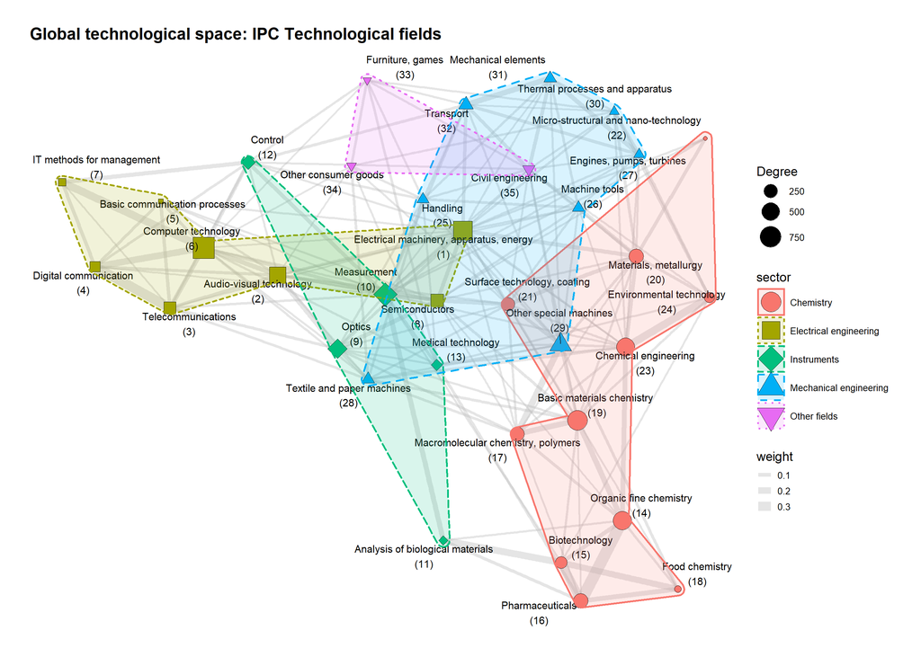

```r
  g_tech_AI %>%  ggraph(layout =  coords_tech_AI) +
  geom_edge_link(aes(width = weight), alpha = 0.4, colour = "grey") +
  geom_node_point(aes(fill = sector, size = 1000^dgr, shape= sector))+ #
  scale_shape_manual(values=c(21, 22, 23, 24, 25)) + scale_size("Degree", range = c(2, 12)) +
  geom_node_text(aes(label = paste0(field_name, "\n(", name, ")")), size = 4, repel = TRUE) +  #field_name or name
  theme_graph(base_family = "sans")+  ggtitle("Global technological space: IPC Technological fields") +
  theme(legend.title = element_text(size = 14), legend.text = element_text(size = 10)) +
  guides(colour = guide_legend(override.aes = list(size=10)))+
  geom_mark_hull(aes(x = x, y=y, colour = sector, fill= sector,
                     linetype = sector), alpha = 0.15, expand = unit(2.5, "mm"), size = 1)
```

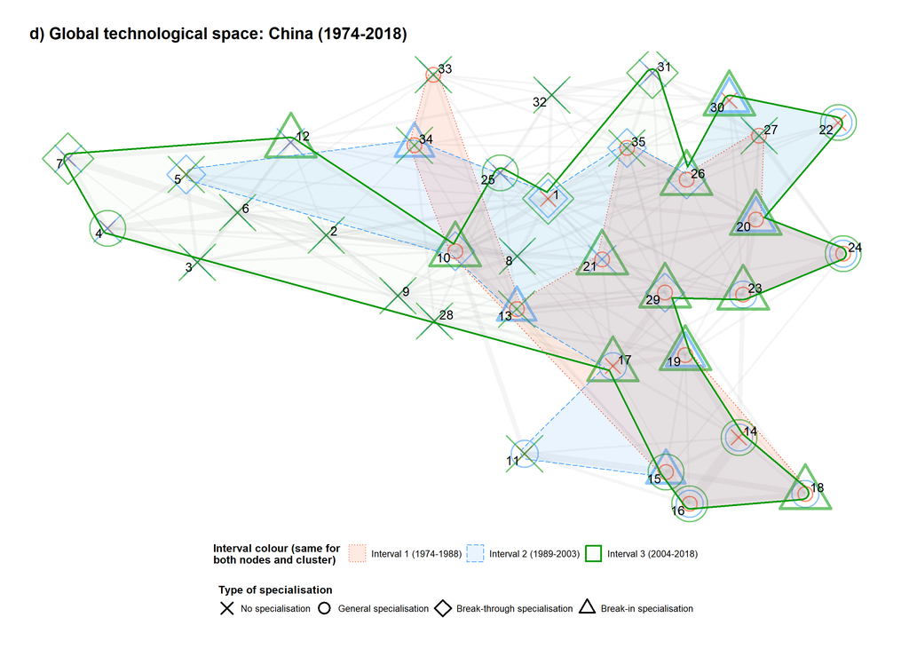

```r
#GTS with specialisations per country
country_select <- c("CN", "US", "JP", "KR")
### 1.2.3.3. Third Country
i=1
IPC_RCAs_wide_simplified <- IPC_RCAs_Top4 %>% pivot_wider(id_cols = c(ctry_code, techn_field_nr, Label),
    names_from = Period_sim,
    values_from = c(RCA_AI_Period, Total_RCA_2, RCA_Gen, RCA_AI, Round_general, Round_AI, Total_RCA),
    names_glue = "{.value}_Period_{Period_sim}" )

  g_tech_AI %N>% left_join(IPC_RCAs_wide_simplified %>%
                             filter(ctry_code == country_select[i]) %>%
                             select(-ctry_code), by = c("name" = "techn_field_nr")) %>%
  mutate(Shape_Group_P1_Factor = factor(
    ifelse(is.na(Total_RCA_2_Period_1), "NA_Value", as.character(Total_RCA_2_Period_1)),
    levels = c("0", "1", "2", "3", "NA_Value"))) %>% ggraph(layout = coords_tech_AI) +
  geom_edge_link(aes(width = weight), alpha = 0.2, colour = "#CCCCCC", show.legend = FALSE) +
  geom_node_point(aes(shape = Shape_Group_P1_Factor,
                      size = 5, stroke = ifelse(Total_RCA_2_Period_1 == 3, 2.5, 1.3),
                      alpha = 1), color = "#FF3300", show.legend = c(shape=TRUE, size=FALSE, stroke=FALSE, alpha=FALSE, color=FALSE)) +
  geom_node_point(aes(shape = factor(Total_RCA_2_Period_2),
                      size = 5.5, stroke = ifelse(Total_RCA_2_Period_2 == 3, 2.5, 1.3),
                      alpha = 1), color = "#3399FF", show.legend = FALSE) +
  geom_node_point(aes(shape = factor(Total_RCA_2_Period_3),
                      size = 6.5,stroke = ifelse(Total_RCA_2_Period_3 == 3, 2.5, 1.3),
                      alpha = 1), color = "#009900", show.legend = FALSE) +
  scale_shape_manual(name = "Type of specialisation",
                     values = c("0" = 4, "1" = 1, "2" = 5, "3" = 2, "NA_Value" = 16), breaks = c("0", "1", "2", "3"),
                     labels = c("0" = "No specialisation", "1" = "General specialisation",
                                "2" = "Break-through specialisation", "3" = "Break-in specialisation"),
                     na.translate = FALSE, drop = FALSE) + scale_size("Degree", range = c(7, 18))+
  scale_alpha(guide = "none") +
  #geom_node_label(aes(label = name), size = 2, repel = F) +
  geom_mark_hull(aes(filter = Total_RCA_2_Period_1 > .99, x = x, y = y, fill = "Period 1", group = "Period 1"),
                 concavity = .1, alpha = .11, linetype = "dotted",expand = unit(2, "mm"), size = .5, color = "#FF3300") +
  geom_mark_hull(aes(filter = Total_RCA_2_Period_2 > .99, x = x, y = y, fill = "Period 2", group = "Period 2"),
                 concavity = .1, alpha = .11, linetype = "longdash",expand = unit(2, "mm"), size = .5, color = "#3399FF") +
  geom_mark_hull(aes(filter = Total_RCA_2_Period_3 > .99, x = x, y = y, fill = "Period 3", group = "Period 3"),
                 concavity = .1, alpha = .02, expand = unit(2, "mm"), size = 1, color = "#009900") +
  scale_fill_manual(name = "Interval colour (same for \nboth nodes and cluster)", # New legend for fill
                    values = c("Period 1" = "#FF3300", "Period 2" = "#3399FF", "Period 3" = "#009900"),
                    labels = c("Interval 1 (1974-1988)", "Interval 2 (1989-2003)", "Interval 3 (2004-2018)")) +
  theme_graph(base_family = "sans") +  theme(legend.position = "bottom", #right
                                             legend.box = "vertical", legend.title = element_text(size = 12, face = "bold"),
                                             legend.text = element_text(size = 10), legend.key.size = unit(0.7, "cm") ) +
  ggtitle("d) Global technological space: China (1974-2018)") +
  geom_node_text(aes(label = name), size = 5, repel = TRUE) +  #field_name or name
  guides(shape = guide_legend(title.position = "top",
                              override.aes = list(size = 5, stroke = 1.5, color = "black") ),
         colour = guide_legend(title.position = "top",
                               override.aes = list(linetype = c("solid", "longdash", "dotted"),
                                                   alpha = 1, size = 1, shape = NA) ))
```

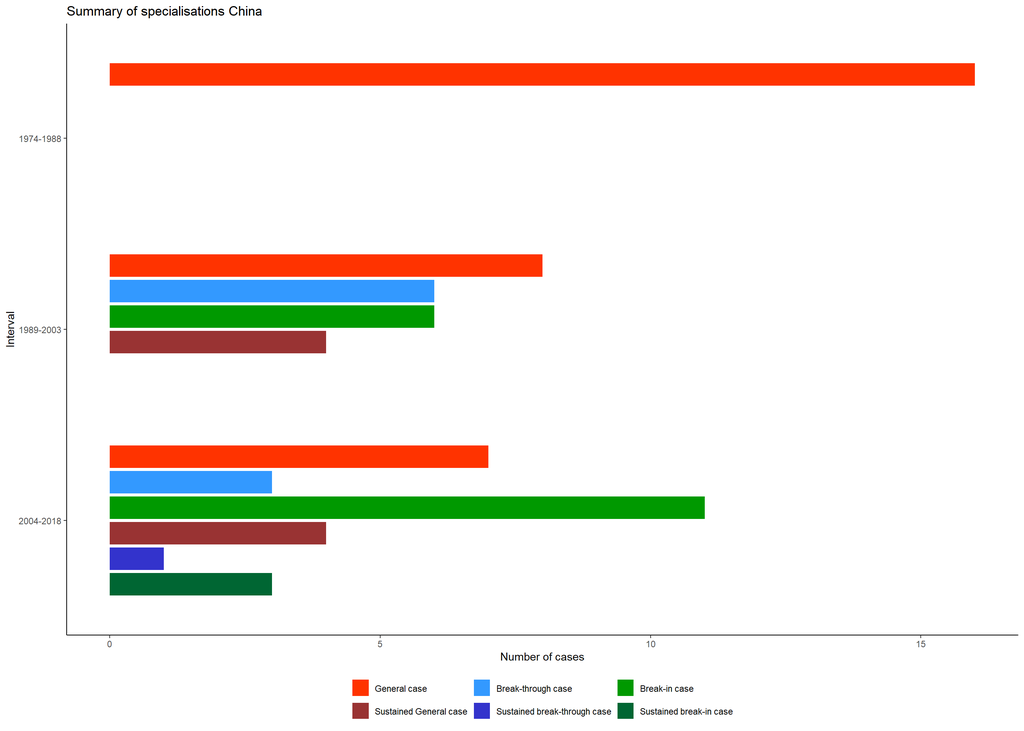

```r
  bar_plot_China <- bar_plot_China <- IPC_RCAs_Top4[IPC_RCAs_Top4$ctry_code == country_select[i],] %>%
  arrange(Label, Period) %>%  group_by(Label) %>%
  mutate( general = Total_RCA_2 == 1,
          break_in              = Total_RCA_2 == 2,
          break_through         = Total_RCA_2 == 3,
          sustained_general    = general  & lag(general, 1, default = FALSE),
          sustained_break_in    = break_in  & lag(break_in, 1, default = FALSE),
          sustained_break_through    = break_through & lag(break_through, 1, default = FALSE)) %>%
  ungroup()

bar_plot_China <- bar_plot_China %>%
  group_by(Period) %>% summarise(`General case`                 = sum(general,           na.rm = TRUE),
                                 `Break-through case`                 = sum(break_in,           na.rm = TRUE),
                                 `Break-in case`            = sum(break_through,      na.rm = TRUE),
                                 `Sustained General case`       = sum(sustained_general, na.rm = TRUE),
                                 `Sustained break-through case`       = sum(sustained_break_in, na.rm = TRUE),
                                 `Sustained break-in case`  = sum(sustained_break_through, na.rm = TRUE),
                                 .groups = "drop") %>% arrange(Period)

plot_long_China <- bar_plot_China |>  rename(Period = Period) |>
  pivot_longer(cols= -Period,names_to= "Indicator",values_to = "Count")

#order labels
plot_long_China$Indicator <- factor(plot_long_China$Indicator, levels = rev(c("General case", "Break-through case",  "Break-in case",
                                                              "Sustained General case", "Sustained break-through case", "Sustained break-in case")))
plot_long_China$Period <- factor(plot_long_China$Period, levels = c("2004-2018", "1989-2003", "1974-1988"))

legend_order <- c(
  "General case", "Break-through case", "Break-in case",
  "Sustained General case", "Sustained break-through case", "Sustained break-in case"
)

  ggplot(plot_long_China, aes(x = factor(Period),y = Count, fill = Indicator)) +
  geom_col(position = position_dodge(width = .8), width = .7) +
  scale_fill_manual(values = c("General case"  = "#FF3300",
    "Sustained General case"  = "#993333",
    "Break-in case"                 = "#009900", #3399FF
    "Sustained break-in case"       = "#006633", #3333CC
    "Break-through case"            = "#3399FF",  #009900
    "Sustained break-through case"  = "#3333CC"),
    breaks = legend_order) + #006633
  guides(fill = guide_legend(nrow = 2, byrow = TRUE)) +
  labs(x = "Interval",y = "Number of cases", fill = NULL, title = NULL)+
  ggtitle("Summary of specialisations China") +
  theme_classic(base_size = 11) + theme(legend.position = "bottom")+ coord_flip()
```

The code is the basically the same for the remaining countries in interval. The countries and intervals are selected by varying the variables i (for countries), and p (for intervals). The figures are generated and combined by country using the custom function “multiplot”. The files are saved at “Files_created_with_the_code/figures/Figure_5_Specialisations_techn_space_3_periods_4_countries_d_China.jpg”, “Files_created_with_the_code/figures/Figure_5_Specialisations_techn_space_3_periods_4_countries_b_USA.jpg”, “Files_created_with_the_code/figures/Figure_5_Specialisations_techn_space_3_periods_4_countries_a_Japan.jpg”, and “Files_created_with_the_code/figures/Figure_5_Specialisations_techn_space_3_periods_4_countries_c_SouthKorea.jpg”.

### 1.3.2. AI-specific technological space (ATS)

Next, we create the ATS. We follow very similar steps: load the AI data, separate the patents that are specific to each interval, calculate the network and it’s coordinates, and plot one technological space per interval. The difference now is that the ATS is dynamic, meaning that we calculate the network every time for each interval. Starting with the first interval, the calculated degree for the top 10 most connected codes is:

```r
g_tech_AI %N>%   arrange(desc(dgr)) %>%  as_tibble() %>%  slice(1:10)
```

| name | sector | field_name | Category | dgr |
| --- | --- | --- | --- | --- |
| 12 | Instruments | Control | AI-core fields | 1.0000000 |
| 6 | Electrical engineering | Computer technology | AI-core fields | 0.9872684 |
| 7 | Electrical engineering | IT methods for management | AI-core fields | 0.8614921 |
| 10 | Instruments | Measurement | AI-core fields | 0.7313958 |
| 25 | Mechanical engineering | Handling | Surrounding fields | 0.5343615 |
| 26 | Mechanical engineering | Machine tools | Other | 0.5229665 |
| 8 | Electrical engineering | Semiconductors | Other | 0.4733882 |
| 32 | Mechanical engineering | Transport | Other | 0.4472136 |
| 27 | Mechanical engineering | Engines, pumps, turbines | Other | 0.4194086 |
| 29 | Mechanical engineering | Other special machines | Other | 0.4165261 |

The dataset with the AI-specific specialisations (named AI_RCA), saved previously in the file “Specializations_All_periods_IPC.csv” (together with the specialisations of countries), looks like this:

```r
head(AI_RCA)
```

|  | techn_field_nr | RCA_AI_Period | Period_sim | Binary |
| --- | --- | --- | --- | --- |
| 1 | 1 | 0.05934926 | 1 | 0 |
| 2 | 2 | 0.08535377 | 1 | 0 |
| 3 | 3 | 0.33606440 | 1 | 0 |
| 4 | 4 | 1.09784935 | 1 | 1 |
| 5 | 5 | 1.64528254 | 1 | 1 |
| 6 | 6 | 16.64849577 | 1 | 1 |

Where “RCA_AI_Period” refers to the specific RTA of each code for each interval (which in turn is shown in the column Period_sim). We then plot the ATS for the first interval:

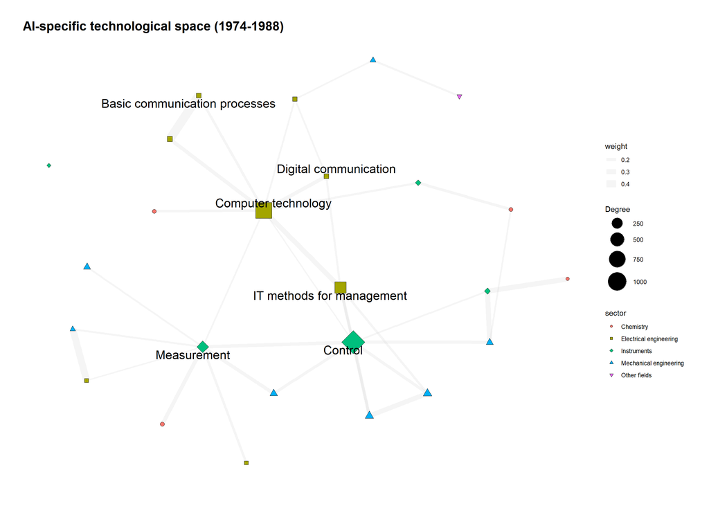

```r
AI_RCA1 <- AI_RCA[AI_RCA$Period_sim == 1,]
p=1
  g_tech_AI %N>%
  left_join(AI_RCA1 %>% filter(Period_sim == p), by = c("name" = "techn_field_nr")) %>%
  ggraph(layout = coords_tech_AI) +
  geom_edge_link(aes(width = weight), alpha = 0.2, colour = "#CCCCCC") +
  geom_node_point(aes(fill = sector, size = 1000^dgr, shape= sector)) +
  scale_shape_manual(values=c(21, 22, 23, 24, 25)) + labs(color   = "RCA")+ scale_size("Degree", range = c(2, 12)) +
  geom_node_text(aes(filter=Binary > .99, label = field_name), size = 6, repel = TRUE) +
  theme_graph(base_family = "sans") + guides(colour = guide_legend(override.aes = list(size=5)))+
  ggtitle("AI-specific technological space (1974-1988)") #
```

We do the same for the 2 other intervals, and combine the three figures again using the multiplot custom function. The resulting figure is saved at “Files_created_with_the_code/figures/Figure_2_ATS_and_AI_core_technologies_3_intervals.jpg”

# 2. Other figures

Next, we create the 3 remaining figures shown in the paper (namely Figures 1, 6, and 7).

## 2.1. Share of Break-in specialisations (Fig 6 and 7)

We create this figure by reading all the summary files we already separated before. We start by reading and combining files RCA_4countries_detailed.csv and Specializations_All_periods_IPC.csv into a new file named IPC_RCAs. Then, we summarize its main results, in the following way:

```r
SummaryAllData<-distinct(IPC_RCAs, ctry_code, Period, .keep_all = TRUE)
colnames(SummaryAllData)[1] <- "Country"
head(SummaryAllData)
```

| Country | techn_field_nr | RCA_Gen | RCA_AI | Period | Label | Round_general | Round_AI | Total_RCA | Period_sim | RCA_AI_Period | Total_RCA_2 | Coiciding | justGeneral | OnlyAI | Share_coinciding | Share_OnlyAI | sum_coinciding | sum_justGeneral | sum_OnlyAI |
| --- | --- | --- | --- | --- | --- | --- | --- | --- | --- | --- | --- | --- | --- | --- | --- | --- | --- | --- | --- |
| China | 1 | 0.7812853 | 0.0000000 | 1974-1988 | Electrical machinery, apparatus, energy | 0 | 0 | 0 | 1 | 0.05934926 | 0 | 0 | 0 | 0 | 0.0000000 | NaN | 0 | 16 | 0 |
| Japan | 1 | 1.1268685 | 1.4025974 | 1974-1988 | Electrical machinery, apparatus, energy | 1 | 1 | 2 | 1 | 0.05934926 | 3 | 1 | 0 | 0 | 0.5882353 | 0.3750 | 10 | 7 | 6 |
| South Korea | 1 | 0.8859104 | 0.0000000 | 1974-1988 | Electrical machinery, apparatus, energy | 0 | 0 | 0 | 1 | 0.05934926 | 0 | 0 | 0 | 0 | 0.0000000 | NaN | 0 | 14 | 0 |
| USA | 1 | 0.8061303 | 0.0000000 | 1974-1988 | Electrical machinery, apparatus, energy | 0 | 0 | 0 | 1 | 0.05934926 | 0 | 0 | 0 | 0 | 0.1764706 | 0.6250 | 3 | 14 | 5 |
| China | 1 | 0.6857667 | 2.0853982 | 1989-2003 | Electrical machinery, apparatus, energy | 0 | 1 | 1 | 2 | 0.22744828 | 2 | 0 | 0 | 1 | 0.4285714 | 0.5000 | 6 | 8 | 6 |
| Japan | 1 | 1.1395992 | 0.9834465 | 1989-2003 | Electrical machinery, apparatus, energy | 1 | 0 | 1 | 2 | 0.22744828 | 1 | 0 | 1 | 0 | 0.5625000 | 0.4375 | 9 | 7 | 7 |

This file is all we need to create Figure 6, shown below (and saved in file “Files_created_with_the_code/figures/Figure_6_Share_coinciding_specialisations_techn_field.jpg”)

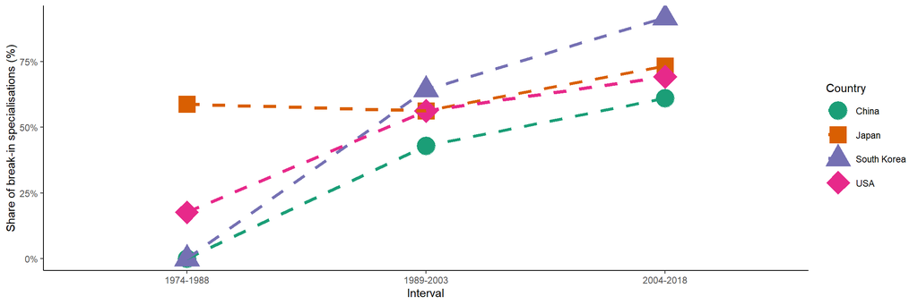

```r
  ggplot(data=SummaryAllData, aes(x=Period, y=Share_coinciding, group=Country, shape = Country, color=Country)) +
  geom_point(aes(fill = Country), size=8) +   scale_shape_manual(values=c(21, 22, 24, 23)) +
  xlab("Interval") +  ylab("Share of break-in specialisations (%)") +
  theme_classic() +  geom_line(aes(color=Country), linetype = "dashed", size=1.5)+
  scale_y_continuous(labels = scales::percent) +
  scale_fill_manual(values = c("#1B9E77", "#D95F02", "#7570B3", "#E7298A")) +
  scale_color_manual(values = c("#1B9E77", "#D95F02", "#7570B3", "#E7298A"))
```

Next, we do the same for the subclass-based Figure 7, which is shown belown and saved as “Files_created_with_the_code/figures/Figure_7_Share_coinciding_specialisations_subclass.jpg”.

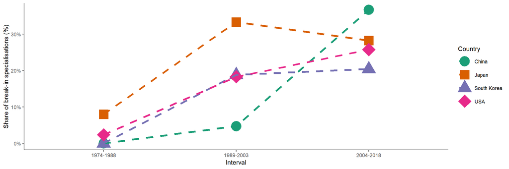

```r
  ggplot(data=SummaryAllData4dig, aes(x=Period, y=Share_coinciding, group=Country, shape = Country, color=Country)) +
  geom_point(aes(fill = Country), size=8) +
  scale_shape_manual(values=c(21, 22, 24, 23)) +
  xlab("Interval") +
  ylab("Share of break-in specialisations (%)") +
  theme_classic() +
  geom_line(aes(color=Country), linetype = "dashed", size=1.5)+
  scale_y_continuous(labels = scales::percent) +
  scale_fill_manual(values = c("#1B9E77", "#D95F02", "#7570B3", "#E7298A")) +
  scale_color_manual(values = c("#1B9E77", "#D95F02", "#7570B3", "#E7298A"))
```

## 2.2. Log 10 of the number of AI patents by Japan, the USA, South Korea, and China

Next, we create Figure 1. Not much data is needed for this one (the only dataset needed is other_files/IPCs_AI.csv), and just simple commands used to process this data to get a summarized number. The produced figure is saved as “Files_created_with_the_code/figures/Figure_1_Log_10_AI_patents_per_country.jpg”, and also shown below.

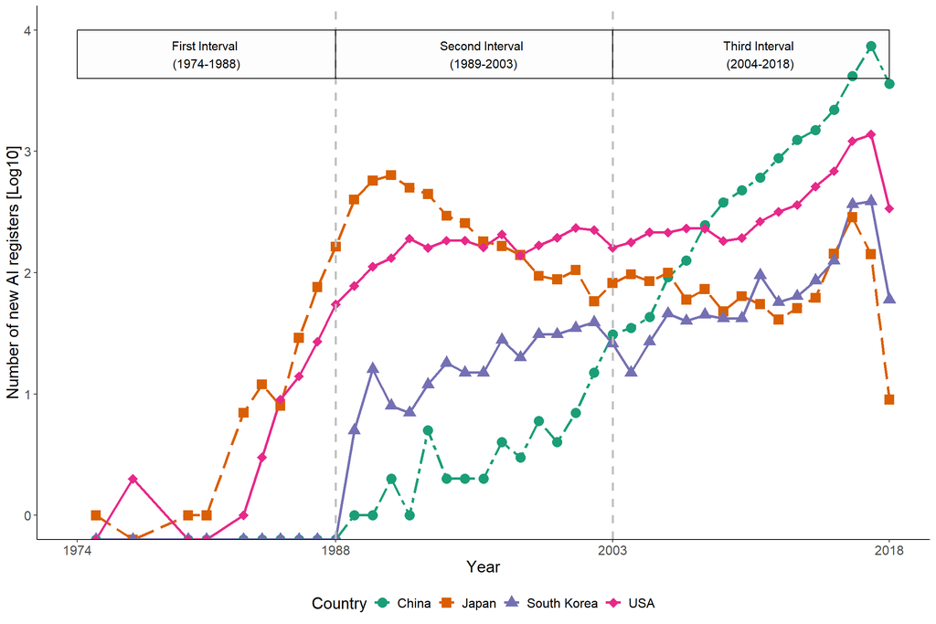

```r
  ggplot(data=test, aes(x=Year, y=log10(Number_of_AI_patents), group=Country, colour=Country, shape=Country)) +
  geom_line(size=1.2, aes(linetype=Country)) +
  geom_point(size=4) +  xlab("Year") +  ylab("Number of new AI registers [Log10]") + theme_classic() +
  scale_linetype_manual(values=c("twodash", "longdash", "solid", "solid")) +
  scale_shape_manual(values=c(16, 15, 17, 18)) + theme(legend.position="bottom") +
  theme(text = element_text(size = 15)) +  scale_y_continuous(limits=c(0,4)) +
  geom_vline(data=test, aes(xintercept=c(1988),  colour=Period), linetype="dashed", size=1, color = "grey") +
  geom_vline(data=test, aes(xintercept=c(2003),  colour=Period), linetype="dashed", size=1, color = "grey") +
  scale_x_continuous(breaks = c(1974, 1988, 2003, 2018), limits=c(1974, 2018)) + scale_color_brewer(palette="Dark2") +
  annotate("rect", xmin = 1974, xmax=1988, ymin = 3.6, ymax = 4, alpha = .01, color = "black") +
  annotate("text", x = 1981, y = 3.8, label = c("First Interval \n(1974-1988)"), size=4)+
  annotate("rect", xmin = 1988, xmax=2003, ymin = 3.6, ymax = 4, alpha = .01, color = "black") +
  annotate("text", x = 1996, y = 3.8, label = c("Second Interval \n(1989-2003)"), size=4) +
  annotate("rect", xmin = 2003, xmax=2018, ymin = 3.6, ymax = 4, alpha = .01, color = "black") +
  annotate("text", x = 2011, y = 3.8, label = c("Third Interval \n(2004-2018)"), size=4)
```

# 3. Permutations for technological fields

## 3.1. Permutate the AI dataset

Load the raw data, separate the interval (the first one for this example, from 1974 to 1988), and calculate the fractional count of each country in each considered field as done before.

The resulting count of techn_fields per country is:

```r
head(region_tech_fields_1_df)
```

| ctry_code | techn_field_nr | n_tech_reg |
| --- | --- | --- |
| AD | 20 | 1 |
| AD | 24 | 1 |
| AD | 28 | 3 |
| AD | 32 | 1 |
| AD | 33 | 1 |
| AD | 34 | 3 |

Now we load the AI patents, select the ones from the first interval, define target countries (the four main ones), and define the number of permutations. To avoid that it takes it too long, I’ll use 10 permutations (num_permutations = 10; in the paper, this number is set to 1000).

```r
list_of_permuted_dfs <- vector("list", length = num_permutations)

for (p in 1:num_permutations) {
  if (p %% 100 == 0) print(paste("Permutation number:", p)) # Progress indicator

  # This dataframe will hold the permuted AI patents for target countries ONLY for THIS iteration
  permuted_ai_for_target_countries_iter <- data.frame()

  for (country in target_countries) {
    # 1. Identify and Count ACTUAL AI patents for the current country from the original AI dataset
    actual_ai_appln_ids_country <- ai_patents_period_1_df %>%
      filter(ctry_code == country) %>%
      distinct(appln_id) %>%
      pull(appln_id)

    n_ai_country <- length(actual_ai_appln_ids_country)

    if (n_ai_country == 0) {
      # print(paste("No AI patents found for", country, "in original AI data. Skipping for perm", p))
      next # Skip to the next country if no AI patents to replace
    }

    # 2. Prepare the pool of ALL patents for the current country from the general dataset
    country_all_patents_pool <- ipc_all_patents_first_period_df %>%
      filter(ctry_code == country) %>%
      distinct(appln_id)

    if (nrow(country_all_patents_pool) == 0) {
      # print(paste("No patents in general pool for", country, ". Skipping for perm", p))
      next
    }

    # Handle cases where the pool is smaller than the number of AI patents to sample
    # This is unlikely if ipc_all_patents_first_period_df is complete, but good for robustness
    sample_size <- min(n_ai_country, nrow(country_all_patents_pool))
    replace_sampling <- FALSE
    if (n_ai_country > nrow(country_all_patents_pool)) {
      # print(paste("Warning: For country", country, "in perm", p,
      #             "not enough unique patents in pool. Sampling", nrow(country_all_patents_pool),
      #             "instead of", n_ai_country, "OR consider sampling with replacement."))
      # Decide: either sample fewer (as done with min()), or sample with replacement.
      # If sampling with replacement is desired:
      # sample_size <- n_ai_country
      # replace_sampling <- TRUE
      # For now, we sample up to the available pool size without replacement.
      # Or, if strict adherence to n_ai_country is needed and pool is too small WITH replace=FALSE:
      if(nrow(country_all_patents_pool) < n_ai_country && !replace_sampling){
        # print(paste("Strict N_AI needed, but pool too small for", country, "in perm", p, ". Skipping country for this perm."))
        next # Skip this country for this permutation if not enough patents
      }
    }


    # 3. Randomly select an equivalent number of unique appln_ids from this country's general pool
    random_appln_ids_country <- sample(country_all_patents_pool$appln_id,
                                       size = sample_size, # Use adjusted sample_size
                                       replace = replace_sampling) # Use replace_sampling flag

    # 4. Get all rows for these randomly selected patents from the ipc_all_patents_first_period_df
    randomly_selected_patents_df_country <- ipc_all_patents_first_period_df %>%
      filter(appln_id %in% random_appln_ids_country & ctry_code == country)

    # 5. Add these randomly selected patents for the current country to the iteration's df
    if (nrow(randomly_selected_patents_df_country) > 0) {
      permuted_ai_for_target_countries_iter <- bind_rows(
        permuted_ai_for_target_countries_iter,
        randomly_selected_patents_df_country
      )
    }
  } # End of country loop

  # Add the permutation number to all rows of this iteration's dataframe
  if (nrow(permuted_ai_for_target_countries_iter) > 0) {
    permuted_ai_for_target_countries_iter$permutation_number <- p
  }

  # Store the dataframe for this iteration in the list
  list_of_permuted_dfs[[p]] <- permuted_ai_for_target_countries_iter

} # End of permutation loop

# Combine all permuted dataframes from the list into one large dataframe
final_permuted_dataset <- bind_rows(list_of_permuted_dfs)
```

```r
head(final_permuted_dataset)
```

|  | appln_id | ctry_code | techn_field_nr | permutation_number |
| --- | --- | --- | --- | --- |
| 1 | 24990549 | JP | 32 | 1 |
| 2 | 25045836 | JP | 1 | 1 |
| 3 | 25045836 | JP | 1 | 1 |
| 4 | 25045836 | JP | 1 | 1 |
| 5 | 25045836 | JP | 1 | 1 |
| 6 | 25045836 | JP | 1 | 1 |

```r
tail(final_permuted_dataset)
```

|  | appln_id | ctry_code | techn_field_nr | permutation_number |
| --- | --- | --- | --- | --- |
| 11576 | 53148002 | US | 35 | 10 |
| 11577 | 48559837 | US | 14 | 10 |
| 11578 | 48559837 | US | 14 | 10 |
| 11579 | 47774217 | US | 1 | 10 |
| 11580 | 54281985 | US | 13 | 10 |
| 11581 | 54281985 | US | 13 | 10 |

Or, in summary, it looks like this (please don’t forget that just Japan and the USA from the 4 selected countries had patents in the first interval):

```r
final_permuted_dataset %>%
  filter(permutation_number <= 5) %>%
  group_by(permutation_number, ctry_code) %>%
  summarise(unique_appln_ids = n_distinct(appln_id), .groups = 'drop') %>%
  print(n=20)
```

```
## # A tibble: 10 × 3
##    permutation_number ctry_code unique_appln_ids
##                 <int> <chr>                <int>
##  1                  1 JP                     307
##  2                  1 US                     107
##  3                  2 JP                     307
##  4                  2 US                     107
##  5                  3 JP                     307
##  6                  3 US                     107
##  7                  4 JP                     307
##  8                  4 US                     107
##  9                  5 JP                     307
## 10                  5 US                     107
```

Next, we separate the list of NOT-targeted countries with AI patents, create a list to hold the replicated dataframes, and loop these countries according to the number of permutations selected (10 in this example), so that we also have these ‘extra’ AI-players on every permutation.

The resulting dataset looks like this for the first and last 6 observations

```r
head(replicated_not_selected_ai_final)
```

| appln_id | ctry_code | permutation_number |
| --- | --- | --- |
| 16723353 | FR | 0 |
| 16723353 | FR | 0 |
| 16723353 | FR | 0 |
| 36147193 | IE | 0 |
| 36147193 | IE | 0 |
| 36147193 | IE | 0 |

```r
tail(replicated_not_selected_ai_final)
```

| appln_id | ctry_code | permutation_number |
| --- | --- | --- |
| 16709578 | DE | 10 |
| 16709578 | DE | 10 |
| 16709578 | DE | 10 |
| 10332913 | DE | 10 |
| 10332913 | DE | 10 |
| 10332913 | DE | 10 |

We merge this back into the “target” dataset, name the country_code of it as “AI_pat” to be able to trace it back, and merge everything.

The result looks like this:

```r
table(final_permuted_dataset$permutation_number)
```

```
##
##    0    1    2    3    4    5    6    7    8    9   10
## 1418 1126 1095 1193 1155 1199 1100 1160 1255 1171 1188
```

## 3.2. Calculate AI-specific specialisations

Now we calculate the AI-specific specialisations based on these Permuted dataset:

```r
list_of_rca_dfs <- region_tech_fields_perm_df %>%
  group_by(permutation_number) %>%
  group_split() %>% # This splits the df into a list of dfs, one for each permutation
  purrr::map(~{
    current_permutation_number <- unique(.x$permutation_number)
    print(paste("Processing RCA for permutation_number:", current_permutation_number))

    # Matrix creation for the current permutation's data
    mat_reg_tech_perm_AI <- .x %>%
      select(-permutation_number) %>% # Temporarily remove for pivot if it causes issues
      arrange(techn_field_nr, ctry_code) %>%
      pivot_wider(names_from = techn_field_nr,
                  values_from = n_tech_reg,
                  values_fill = 0) # Changed from list(n_tech_reg = 0) for simplicity

    # Check if ctry_code column exists and is not empty
    if (!"ctry_code" %in% names(mat_reg_tech_perm_AI) || nrow(mat_reg_tech_perm_AI) == 0 || all(is.na(mat_reg_tech_perm_AI$ctry_code))) {
      print(paste("Skipping permutation", current_permutation_number, "due to missing ctry_code or empty data after pivot."))
      return(NULL) # Return NULL or an empty tibble
    }

    # Check for duplicate ctry_codes which would prevent rownames_to_column
    if (any(duplicated(mat_reg_tech_perm_AI$ctry_code))) {
      print(paste("Warning: Duplicate ctry_code found for permutation", current_permutation_number, ". Aggregating or handling needed."))
      return(tibble(permutation_number = current_permutation_number, error="duplicate ctry_code"))
    }


    mat_reg_tech_perm_AI <- mat_reg_tech_perm_AI %>%
      remove_rownames() %>%
      column_to_rownames(var = "ctry_code") %>%
      as.matrix() %>%  round()# No rounding here, location_quotient might prefer raw numbers

    # RCA calculation
    # Ensure matrix is suitable (e.g., no NA/NaN/Inf that location_quotient can't handle)
    if (nrow(mat_reg_tech_perm_AI) == 0 || ncol(mat_reg_tech_perm_AI) == 0) {
      print(paste("Skipping RCA for permutation", current_permutation_number, "due to empty matrix."))
      return(NULL)
    }

    # Ensure there are at least two columns for location_quotient (ctry_code was one)
    if (ncol(mat_reg_tech_perm_AI) < 1) { # If only ctry_code was present and now it's rownames
      print(paste("Skipping RCA for permutation", current_permutation_number, "due to insufficient columns in matrix."))
      return(NULL)
    }


    # Check for all zero rows/columns if location_quotient is sensitive
    # For example, if a row sum is 0, RCA might be NaN or Inf.
    # The location_quotient function might handle this, or you might need pre-filtering.

    rca_results_perm <- tryCatch({
      mat_reg_tech_perm_AI %>%
        location_quotient(binary = FALSE) %>%
        as.data.frame() %>%
        rownames_to_column("ctry_code") %>%
        as_tibble() %>%
        gather(key = "techn_field_nr", value = "RCA", -ctry_code) %>%
        arrange(ctry_code, techn_field_nr) %>%
        mutate(permutation_number = current_permutation_number) # Add back permutation number
    }, error = function(e) {
      print(paste("Error in location_quotient for permutation", current_permutation_number, ":", e$message))
      return(tibble(permutation_number = current_permutation_number, ctry_code=NA, techn_field_nr=NA, RCA=NA, error_message = e$message)) # Return an empty or error-marked tibble
    })

    return(rca_results_perm)
  })
```

```
## [1] "Processing RCA for permutation_number: 0"
## [1] "Processing RCA for permutation_number: 1"
## [1] "Processing RCA for permutation_number: 2"
## [1] "Processing RCA for permutation_number: 3"
## [1] "Processing RCA for permutation_number: 4"
## [1] "Processing RCA for permutation_number: 5"
## [1] "Processing RCA for permutation_number: 6"
## [1] "Processing RCA for permutation_number: 7"
## [1] "Processing RCA for permutation_number: 8"
## [1] "Processing RCA for permutation_number: 9"
## [1] "Processing RCA for permutation_number: 10"
```

```r
# Combine the list of RCA dataframes into one final dataframe
final_rca_all_permutations_df <- bind_rows(list_of_rca_dfs)
```

The new AI-specific RTAs look like this:

```r
head(final_rca_all_permutations_df)
```

| ctry_code | techn_field_nr | RCA | permutation_number |
| --- | --- | --- | --- |
| AT | 1 | 0 | 0 |
| AT | 10 | 0 | 0 |
| AT | 11 | 0 | 0 |
| AT | 12 | 0 | 0 |
| AT | 13 | 0 | 0 |
| AT | 17 | 0 | 0 |

```r
tail(final_rca_all_permutations_df)
```

| ctry_code | techn_field_nr | RCA | permutation_number |
| --- | --- | --- | --- |
| US | 4 | 0.0000000 | 10 |
| US | 5 | 0.8117647 | 10 |
| US | 6 | 0.3529412 | 10 |
| US | 7 | 0.0000000 | 10 |
| US | 8 | 0.2705882 | 10 |
| US | 9 | 0.8455882 | 10 |

This file (or better said, the relevant file with 1000 permutations) is saved as “final_rca_all_permutations_df_1st_Period.csv”. The other two intervals are saved with similar names, i.e., “final_rca_all_permutations_df_2nd_Period.csv” and “final_rca_all_permutations_df_3rd_Period.csv”, in Files_created_with_the_code/data/files_code_Fields_analysis/robustness/

# 4. Econometrics

Read the files calculated in the “3.Robustness” code, and calculate the first three models.

The dataset looks like this

```r
head(regression_data)
```

|  | ctry_code | rel_density | period | no_specialization | general_specialization | ai_specific_specialization | coinciding_specialization | actual_share_coinciding | actual_share_round_ai | actual_share_round_general | actual_persistent_coinciding | actual_persistent_just_general | actual_persistent_just_ai | actual_n_persistent_round_ai | actual_n_ai_prev_coinciding | actual_n_coinciding_prev_ai | actual_n_ai_prev_gen | actual_n_persistent_core_fields | actual_n_persistent_not_core_fields | actual_n_persistent_coin_core_fields | actual_n_persistent_coin_not_core_fields | actual_ai_core_fields | actual_ai_not_core_fields | actual_persistent_general_all | total_general_specializations | double_check | total_specializations | total_AI_specializations | Share_Coinciding | … |
| --- | --- | --- | --- | --- | --- | --- | --- | --- | --- | --- | --- | --- | --- | --- | --- | --- | --- | --- | --- | --- | --- | --- | --- | --- | --- | --- | --- | --- | --- | --- |
| 1 | JP | 57 | 1974-1978 | 15 | 19 | 0 | 1 | 0.0500000 | 0.02857143 | 0.5714286 | 0 | 0 | 0 | 0 | 0 | 0 | 0 | 0 | 0 | 0 | 0 | 1 | 0 | 0 | 20 | 35 | 20 | 1 | 0.0500000 | … |
| 2 | KR | 38 | 1974-1978 | 22 | 13 | 0 | 0 | 0.0000000 | 0.00000000 | 0.3714286 | 0 | 0 | 0 | 0 | 0 | 0 | 0 | 0 | 0 | 0 | 0 | 0 | 0 | 0 | 13 | 35 | 13 | 0 | 0.0000000 | … |
| 3 | US | 50 | 1974-1978 | 19 | 15 | 0 | 1 | 0.0625000 | 0.02857143 | 0.4571429 | 0 | 0 | 0 | 0 | 0 | 0 | 0 | 0 | 0 | 0 | 0 | 0 | 1 | 0 | 16 | 35 | 16 | 1 | 0.0625000 | … |
| 4 | CN | 35 | 1974-1978 | 24 | 11 | 0 | 0 | 0.0000000 | 0.00000000 | 0.3142857 | 0 | 0 | 0 | 0 | 0 | 0 | 0 | 0 | 0 | 0 | 0 | 0 | 0 | 0 | 11 | 35 | 11 | 0 | 0.0000000 | … |
| 5 | CN | 32 | 1979-1983 | 23 | 12 | 0 | 0 | 0.0000000 | 0.00000000 | 0.3428571 | 0 | 5 | 0 | 0 | 0 | 0 | 0 | 0 | 0 | 0 | 0 | 0 | 0 | 5 | 12 | 35 | 12 | 0 | 0.0000000 | … |
| 6 | JP | 56 | 1979-1983 | 17 | 16 | 0 | 2 | 0.1111111 | 0.05714286 | 0.5142857 | 1 | 15 | 0 | 1 | 0 | 0 | 0 | 1 | 0 | 1 | 0 | 2 | 0 | 17 | 18 | 35 | 18 | 2 | 0.1111111 | … |

The results for the first three models are:

```r
stargazer(model3, model1, model2, title="Effects on the share of break-ins", ci.level=0.95, single.row=TRUE, ci=F, type="text")
```

```
##
## Effects on the share of break-ins
## ===================================================================================================
##                                                        Dependent variable:
##                               ---------------------------------------------------------------------
##                                                         Share_Coinciding
##                                        (1)                    (2)                     (3)
## ---------------------------------------------------------------------------------------------------
## rel_density                       0.001 (0.005)          0.001 (0.006)          -0.001 (0.006)
## total_general_specializations                           -0.010 (0.016)           0.002 (0.018)
## Period1979-1983                   0.004 (0.132)         -0.012 (0.074)          -0.013 (0.075)
## Period1984-1988                   0.164 (0.132)         -0.016 (0.079)          -0.045 (0.084)
## Period1989-1993                  0.348** (0.131)         0.019 (0.085)          -0.005 (0.089)
## Period1994-1998                 0.405*** (0.131)         0.005 (0.093)          -0.002 (0.095)
## Period1999-2003                 0.455*** (0.136)        -0.007 (0.098)          -0.034 (0.103)
## Period2004-2008                 0.535*** (0.132)         0.080 (0.095)           0.048 (0.100)
## Period2009-2013                 0.534*** (0.131)         0.065 (0.096)           0.042 (0.101)
## Period2014-2018                 0.666*** (0.132)         0.118 (0.105)           0.093 (0.110)
## ctry_codeJP                                                                     -0.018 (0.055)
## ctry_codeKR                                                                      0.063 (0.054)
## ctry_codeUS                                                                      0.049 (0.051)
## total_AI_specializations                               0.036*** (0.005)        0.038*** (0.005)
## Constant                         -0.036 (0.227)          0.100 (0.130)           0.017 (0.152)
## ---------------------------------------------------------------------------------------------------
## Observations                           36                     36                      36
## R2                                    0.673                  0.905                   0.915
## Adjusted R2                           0.560                  0.862                   0.859
## Residual Std. Error              0.185 (df = 26)        0.104 (df = 24)         0.105 (df = 21)
## F Statistic                   5.958*** (df = 9; 26) 20.802*** (df = 11; 24) 16.181*** (df = 14; 21)
## ===================================================================================================
## Note:                                                                   *p<0.1; **p<0.05; ***p<0.01
```

For the remaining 3 models, the results are:

```r
stargazer(newmodel4, newmodel5, newmodel6, title="Effects on persisting specialisations", ci.level=0.95, single.row=TRUE, ci=F, type="text")
```

```
##
## Effects on persisting specialisations
## =========================================================================================================
##                                                           Dependent variable:
##                               ---------------------------------------------------------------------------
##                                        actual_persistent_coinciding          actual_n_persistent_round_ai
##                                         (1)                    (2)                       (3)
## ---------------------------------------------------------------------------------------------------------
## rel_density                        0.015 (0.031)          0.039 (0.082)             0.006 (0.078)
## Period1979-1983                   -1.431 (1.171)          0.480 (1.092)             -0.124 (1.044)
## Period1984-1988                   -1.901 (1.120)          -0.941 (1.192)            -0.628 (1.151)
## Period1989-1993                   -1.942 (1.330)          0.423 (1.258)             -0.292 (1.201)
## Period1994-1998                   -1.263 (1.148)          1.854 (1.368)             0.158 (1.354)
## Period1999-2003                   -1.280 (1.234)          1.708 (1.477)             -0.520 (1.447)
## Period2004-2008                   -1.812 (1.245)          0.919 (1.405)             0.807 (1.350)
## Period2009-2013                    0.012 (1.305)         3.546** (1.420)            -1.135 (1.524)
## Period2014-2018                   -0.420 (1.297)          2.861* (1.572)            -0.458 (1.601)
## actual_persistent_general_all     0.133* (0.074)
## actual_n_persistent_round_ai     0.525*** (0.070)
## total_general_specializations                             0.113 (0.239)             -0.053 (0.228)
## actual_persistent_coinciding                                                       1.115*** (0.199)
## coinciding_specialization                                 0.413* (0.226)            -0.182 (0.231)
## total_AI_specializations                                  -0.067 (0.150)           0.297** (0.143)
## Constant                          -0.669 (1.464)         -3.642* (1.955)            0.482 (1.997)
## ---------------------------------------------------------------------------------------------------------
## Observations                            36                      36                        36
## R2                                     0.914                  0.799                     0.921
## Adjusted R2                            0.874                  0.694                     0.875
## Residual Std. Error               0.981 (df = 24)        1.531 (df = 23)           1.458 (df = 22)
## F Statistic                   23.111*** (df = 11; 24) 7.606*** (df = 12; 23)   19.828*** (df = 13; 22)
## =========================================================================================================
## Note:                                                                         *p<0.1; **p<0.05; ***p<0.01
```